# Introduction

## 1 Why do the points move together?

## 200 flights on one route

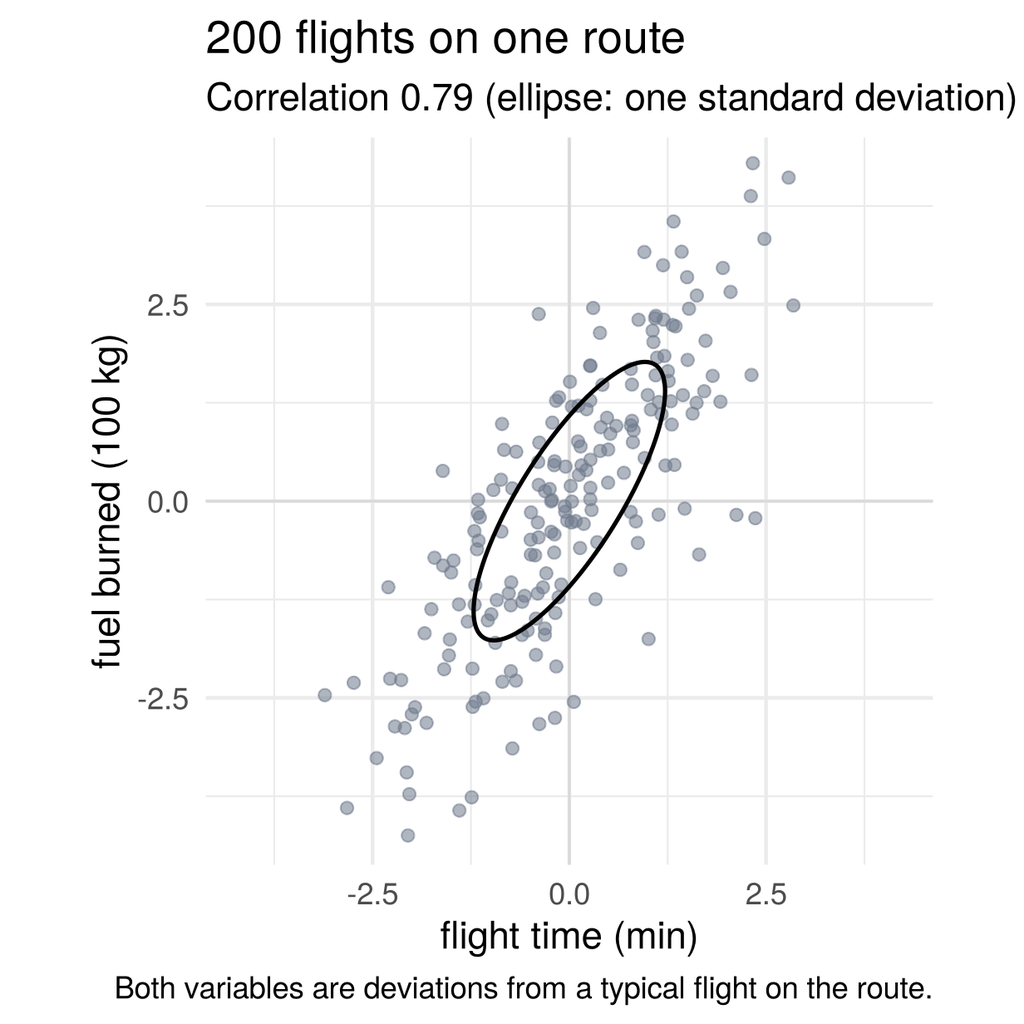

Each point is one flight: **flight time** and **fuel burned**, as deviations from a typical flight. The cloud is **tilted** (correlation 0.79).

- **Why** do the two move together?
- Is there a **common movement** behind both?
- How many movements, and how strongly does each affect each variable?

Multivariate analysis: explain a cloud of correlated data by a few simpler, **unobserved** movements.

## A world without relationships

[interactive chart not shown]

Two **independent** shocks per flight, a **round** cloud:

- headwind \(\varepsilon_1\): stronger wind than usual
- load \(\varepsilon_2\): heavier plane than usual

Press **Play**: the aircraft turns these shocks into flight time and fuel, and we get the tilted cloud of the 200 flights.

Correlated data can come from **independent** forces: the aircraft **combines** them into flight time and fuel.

## 2 From shocks to data

## Each shock moves both measurements

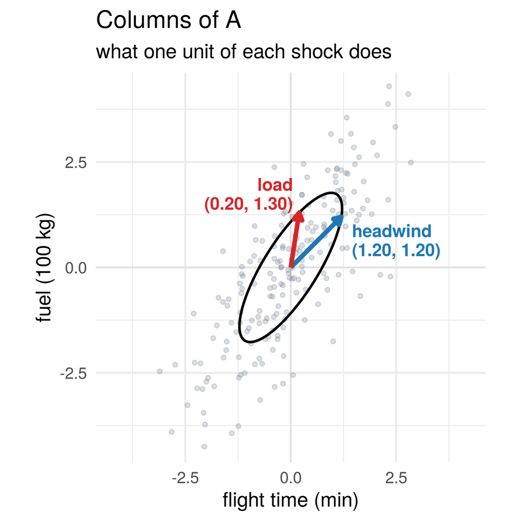

- Headwind (1 sd): 1.20 min longer; at the manual’s 100 kg/min, 120 kg more fuel.
- Load (1 sd, 2 t): 0.20 min and 130 kg more.

Fuel in units of 100 kg:

\[ \begin{aligned} X_1 = \text{time} &= 1.20\,\varepsilon_1 + 0.20\,\varepsilon_2\\ X_2 = \text{fuel} &= 1.20\,\varepsilon_1 + 1.30\,\varepsilon_2 \end{aligned} \]

Each variable: a weighted sum of the **same two shocks**.

## In matrix form: \(X = A\varepsilon\)

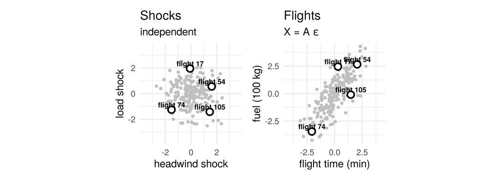

\[ \underset{X}{\begin{pmatrix} X_1\\ X_2\end{pmatrix}} = \underset{A}{\begin{pmatrix} 1.20 & 0.20\\ 1.20 & 1.30\end{pmatrix}} \underset{\varepsilon}{\begin{pmatrix} \varepsilon_1\\ \varepsilon_2\end{pmatrix}} \]

**Row** \(i\) of \(A\): how \(X_i\) responds to each shock.  
**Column** \(j\): how shock \(j\) moves all variables.

Capitals (\(X_1\), \(X_2\)): random, they change from flight to flight. Lower case (\(x_1\), \(x_2\)): the values recorded for one flight.

## A matrix moves space

[interactive chart not shown]

\(A\) moves the **whole plane**: lines stay straight, grid lines parallel and evenly spaced, the origin stays put.

The basis vectors land on the **columns** of \(A\): \[Ae_1=\begin{pmatrix}1.20\\1.20\end{pmatrix},\quad Ae_2=\begin{pmatrix}0.20\\1.30\end{pmatrix}\]

Every other point follows: \(X = \varepsilon_1\,Ae_1 + \varepsilon_2\,Ae_2\).

Idea from 3Blue1Brown, [*Essence of Linear Algebra*](https://www.3blue1brown.com/topics/linear-algebra).

## And back again: whitening

[interactive chart not shown]

The **inverse matrix** moves the plane back: \[\varepsilon = A^{-1}X\]

For every flight: how much headwind, how much load?

**Whitening**: turning correlated variables into uncorrelated, unit-variance shocks (“white noise”).

## 3 The same data, many stories

## Many matrices fit the same cloud

[interactive chart not shown]

## What the data can tell us: \(\Sigma\)

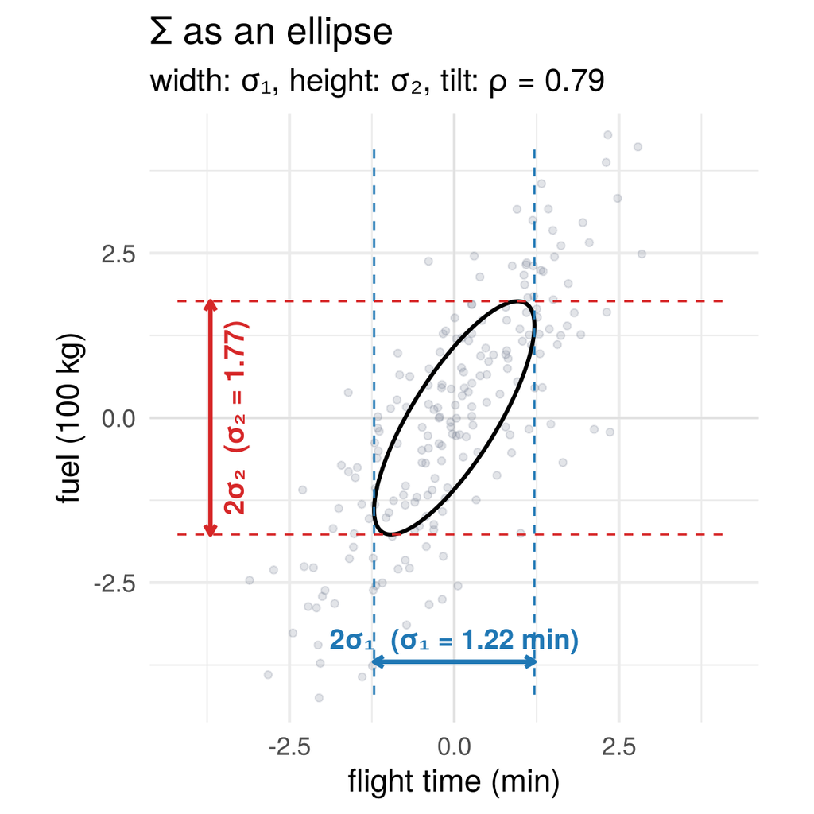

The data pin down only **three numbers**, the covariance matrix:

\[ \Sigma=\begin{pmatrix}\sigma_1^2 & \sigma_{12}\\ \sigma_{12} & \sigma_2^2\end{pmatrix} =\begin{pmatrix}1.48 & 1.70\\ 1.70 & 3.13\end{pmatrix} \]

- \(\sigma_1^2, \sigma_2^2\): variances of flight time and fuel
- \(\sigma_{12}\): covariance; \(\rho = \sigma_{12}/(\sigma_1\sigma_2)\)

The black ellipse **is** a picture of \(\Sigma\).

## What a candidate \(A\) implies: \(\Sigma = AA'\)

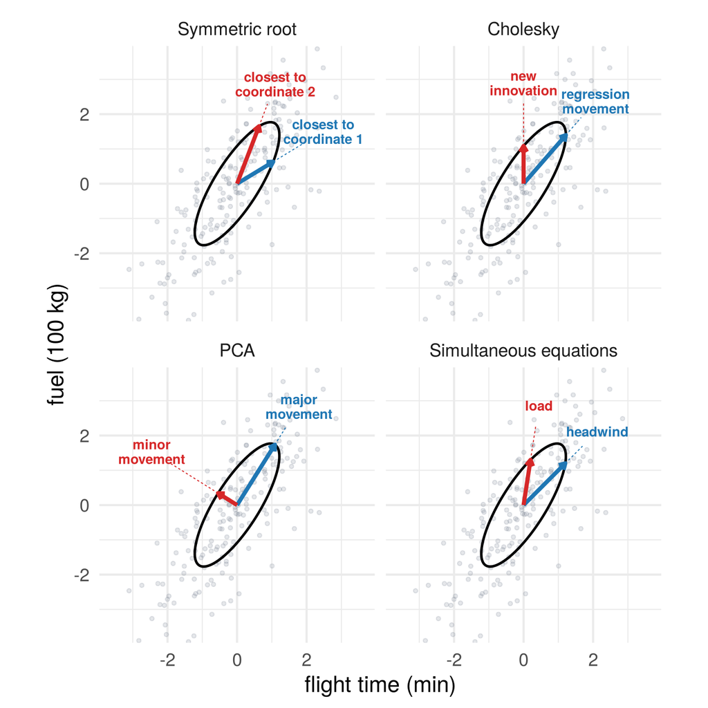

Independent unit-variance shocks: their contributions add up.

\[ \begin{aligned} \sigma_1^2 &= a_{11}^2+a_{12}^2\\ \sigma_2^2 &= a_{21}^2+a_{22}^2\\ \sigma_{12} &= a_{11}a_{21}+a_{12}a_{22} \end{aligned} \]

or in short \(\;\boxed{\Sigma=AA'}\;\): 3 equations, 4 unknowns.

All four \(A\)’s fit the same cloud.

One extra **restriction** is needed: which \(A\) is **useful**?

## 4 Choosing a useful \(A\)

## Symmetric root: \(A = A'\)

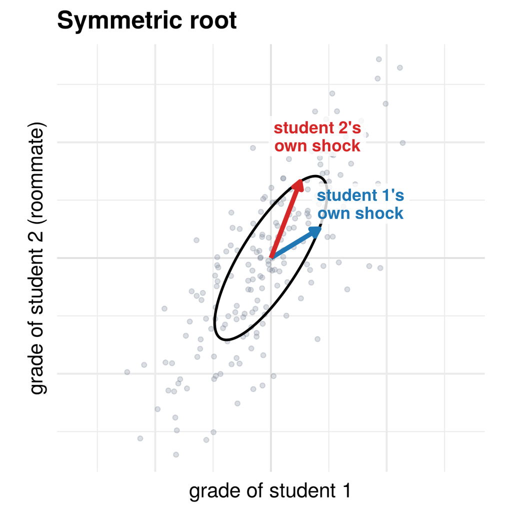

Uncorrelated coordinates that stay **closest to the original variables**.

- **Roommates’ grades.** Random pairs influence each other; neither comes first: \(a_{12} = a_{21}\).

## Cholesky: \(a_{12} = 0\)

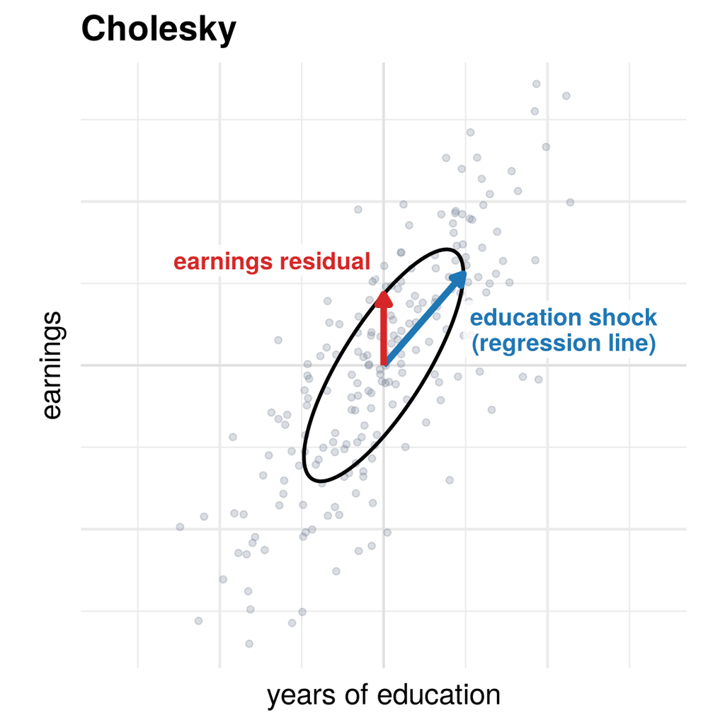

Order the **variables**; \(X_1\) responds only to the first shock.

**Regression** (\(X_1\) education, \(X_2\) earnings): \[ \begin{aligned} X_2 &= \beta X_1 + \sigma_2\varepsilon_2\\ X_1 &= \sigma_1\varepsilon_1 \end{aligned} \] \[ \Rightarrow\quad \begin{pmatrix}X_1\\X_2\end{pmatrix}= \begin{pmatrix}\sigma_1 & 0\\ \beta\sigma_1 & \sigma_2\end{pmatrix} \begin{pmatrix}\varepsilon_1\\\varepsilon_2\end{pmatrix} \]

- **Timing.** Earlier variables first (recursive VARs).

## PCA: first column as long as possible

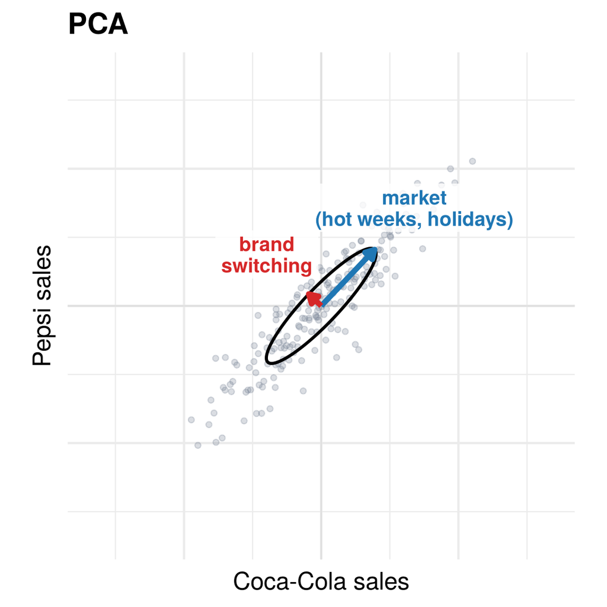

Squared column length = that shock’s share of the **total variance**. PCA makes the first column **longest**; the second is perpendicular.

- **Coke and Pepsi.** Major movement: the soft-drink market. Minor: brand switching.

## Simultaneous equations: a known coefficient

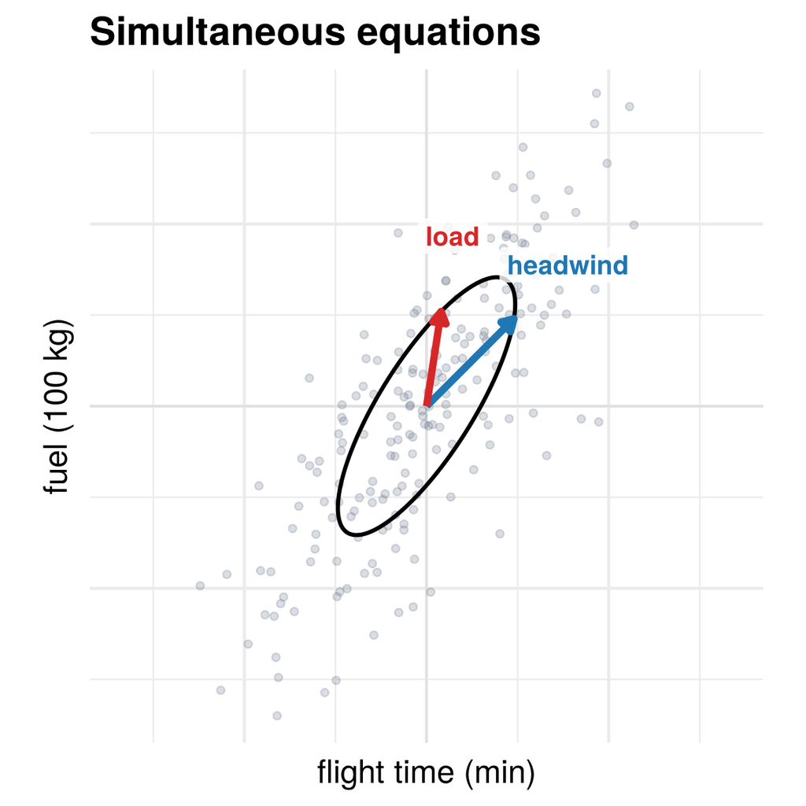

Engineering or economics, not statistics, supplies the restriction.

- **Flights.** Manual: 100 kg per extra cruise minute fixes the headwind direction. The data give the rest: a load shock adds 130 kg but only 12 s.

Choose latent coordinates that make some feature of the data simple or meaningful.

## 5 Structural form, reduced form, sample

## Three layers: nature one way, analysis the other

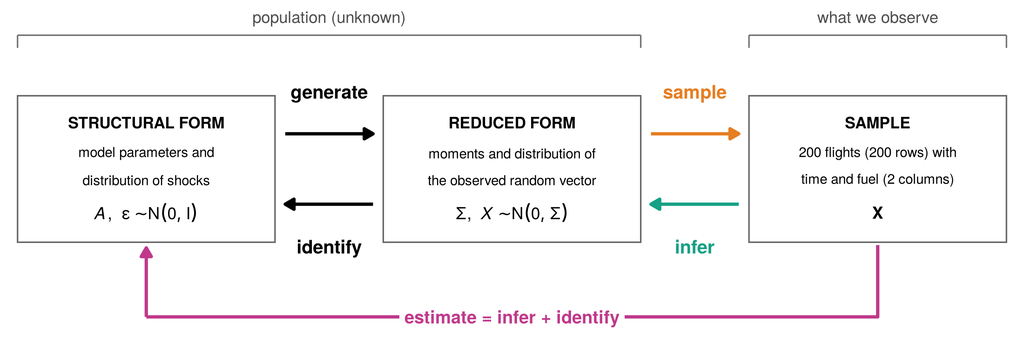

- **Structural form** \(\varepsilon\), \(A\): **why** the variables move together (a circle).
- **Reduced form** \(X = A\varepsilon\), \(\Sigma = AA'\): only **how** (an ellipse).
- **Sample** \(\mathbf X\): the 200 flights we recorded, draws of \(X\).

## How nature produces the data

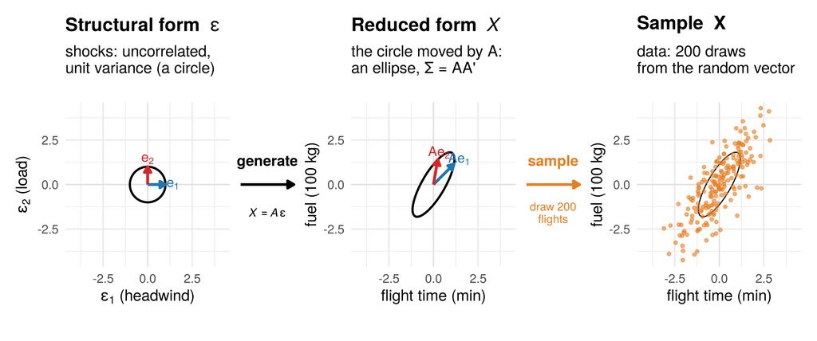

The shocks **generate** the random vector \(X = A\varepsilon\); we **sample** 200 flights from it.

## How we analyse the data

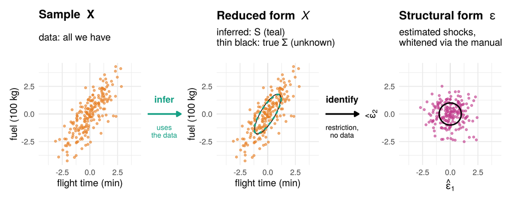

We only ever see the orange points.

## 6 Fewer coordinates: dimension reduction

## Coke and Pepsi: one number per week

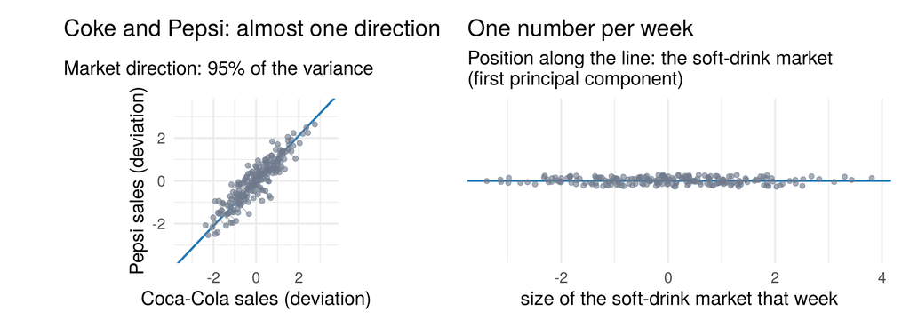

- One big movement (market), one small (brand switching): keep **one number**, not two.
- Many variables, few movements (yield curves, surveys, stock returns): a few numbers per observation describe almost everything.

## 7 Other latent structures

## Factor analysis: two food critics

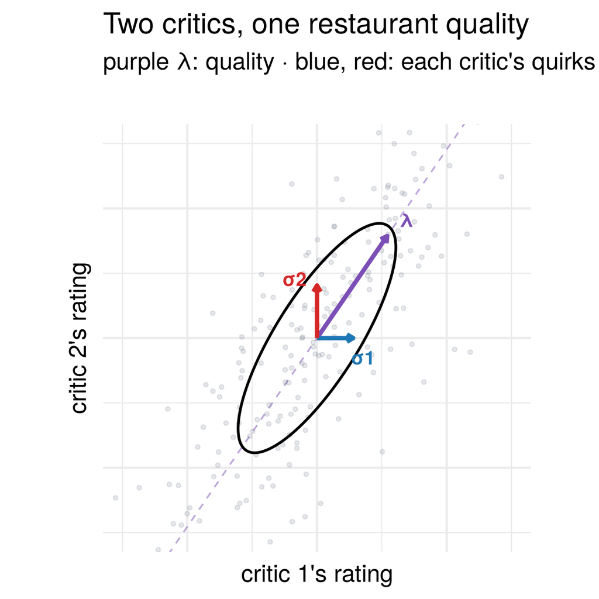

Two critics rate the same restaurants: same food (**common** factor \(f\), quality), own quirks (**unique** shocks).

\[ \begin{aligned} X_1&=\sigma_1\varepsilon_1+\lambda_1 f\\ X_2&=\sigma_2\varepsilon_2+\lambda_2 f \end{aligned} \] \[ A=\begin{pmatrix}\sigma_1 & 0 & \lambda_1\\ 0 & \sigma_2 & \lambda_2\end{pmatrix} \]

3 reduced + 1 free = 4 par. (\(\lambda_1, \lambda_2, \sigma_1, \sigma_2\)). Open: how the noise is **split**.

## All one-factor stories that fit the critics

[interactive chart not shown]

## Four natural restrictions

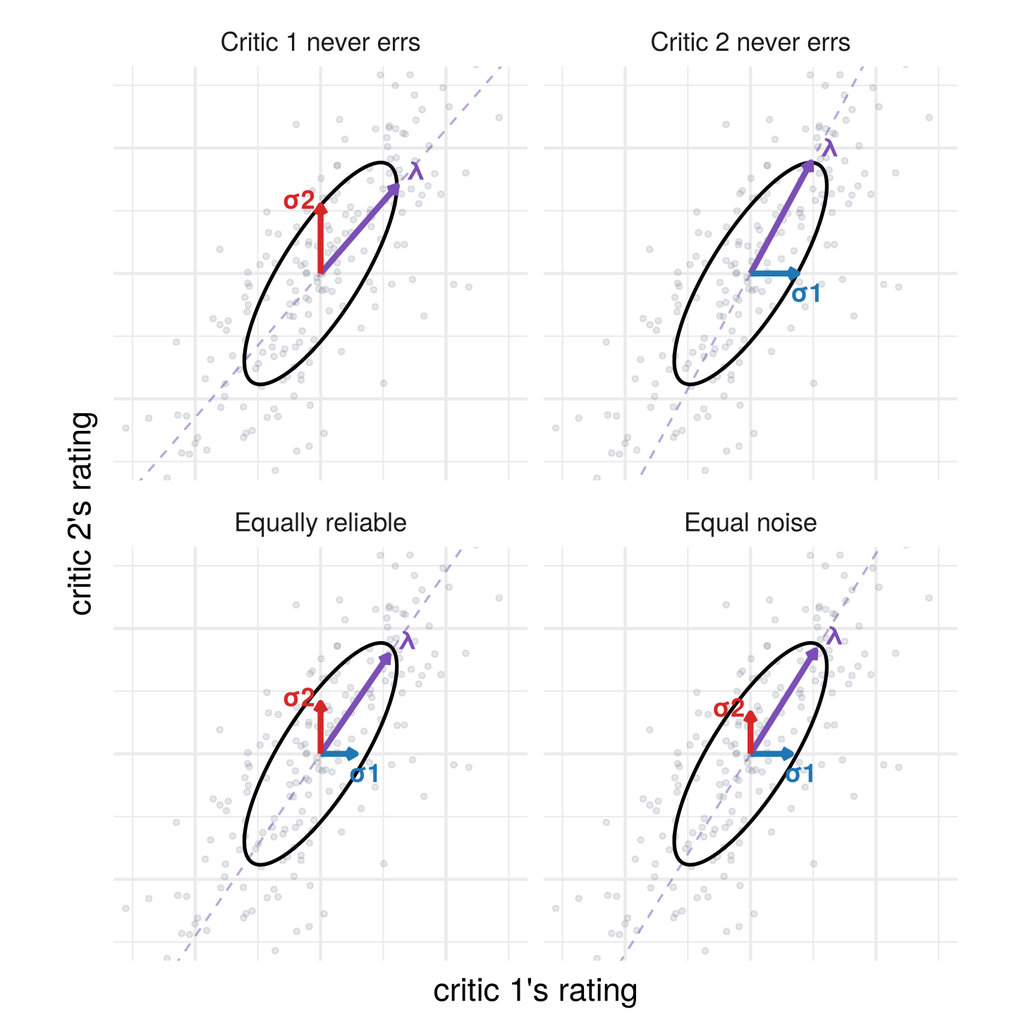

- **Critic 1 never errs** (\(\sigma_1 = 0\)): her rating *is* the quality; critic 2 is a regression on her. Exactly **Cholesky**.
- **Critic 2 never errs**: the same, critic 2 first.
- **Equally reliable** (equal communalities): quality explains the **same share** of each critic’s rating variance.
- **Equal noise** (\(\sigma_1 = \sigma_2\)): both critics’ quirks are equally large.

## A discrete latent variable: clustering

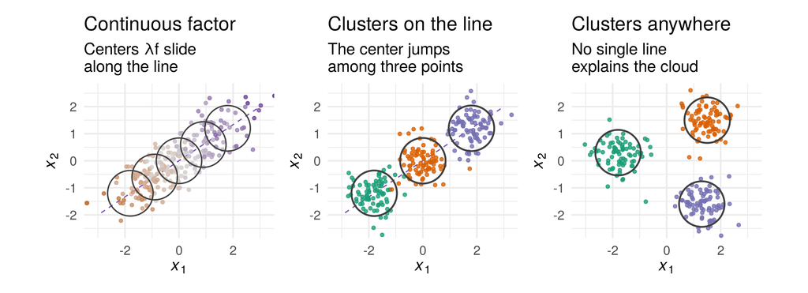

- Factor model: the center \(\lambda f\) **slides**. Clustering: it **jumps** among groups.
- Theory (CFA, SEM) fixes entries of \(A\) to zero, like Cholesky and the headwind.

## A different distance: MDS on a loop road

[interactive chart not shown]

## What multidimensional scaling does

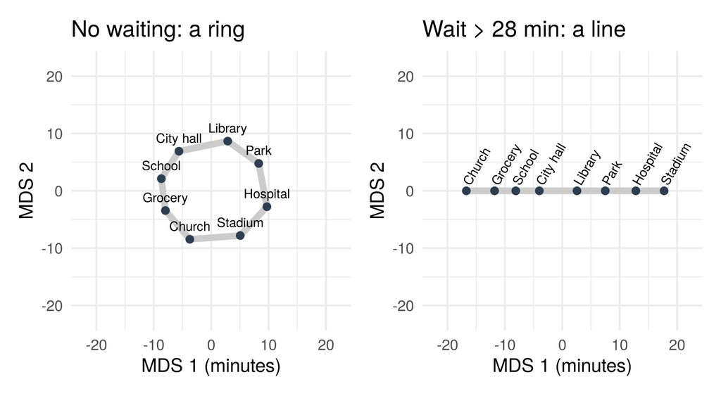

MDS turns **travel times** into coordinates whose straight-line distances reproduce them.

A construction-site wait opens the ring; beyond 27.9 min nobody drives through it, and one dimension suffices.

First turn the distances we care about into coordinates, then treat them like any data.

## 8 The road ahead

## Coming lectures: structural models

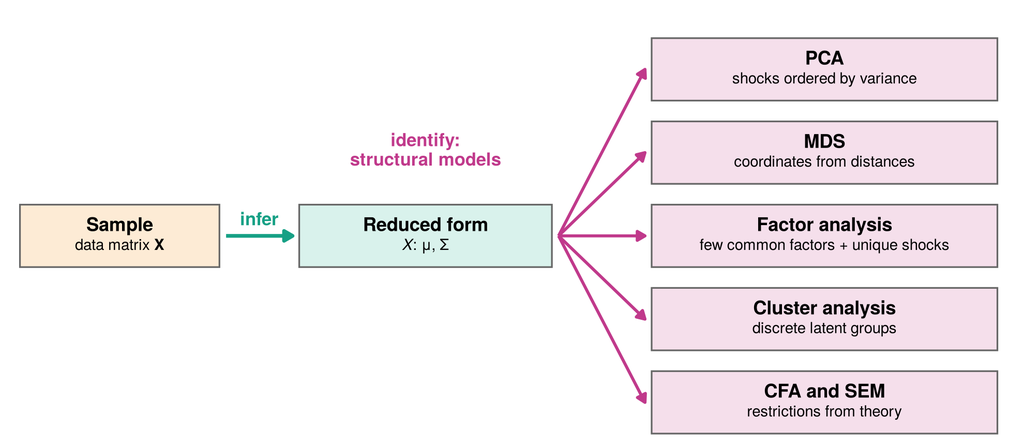

First the **sample** (looking at data), then the **reduced form** (distributions), then structural models, each with its own identifying assumptions.

## Summary

## Takeaways

- Independent shocks form a **round** cloud; a system \(A\) **combines** them into a tilted cloud. Undoing \(A\) (whitening) recovers the shocks.
- The data reveal only the **reduced form** \(\Sigma\). Every rotation of \(A\) gives the same \(\Sigma = AA'\), so one extra **restriction** picks a structural form: symmetry, an ordering, the longest first column, or a known coefficient.
- **Infer** (sample → reduced form) + **identify** (reduced form → structural form) = **estimate**.
- A structural model **explains** the data and can **compress** them.
- \(X = A\varepsilon\) is one structural model. Factors and clusters change the latent structure. MDS first rebuilds coordinates from the distances we care about, then the same ideas apply.

Which latent coordinates make the multivariate data easier to understand?